# USA SCADA Check README

Bently Bartee

2024-02-05

## USA SCADA Check how to use

The SCADA Check is ran in R using the R Shiny web applications. This will make it easy and user friendly for all to use. This readme file will walk you through these items:

- How to access and where its located.
- What is needed to run, what R packages will need to be loaded.
- Steps to fill out the web SCADA Check.

### How to access and where its located

The SCADA Check is stored on the AWS server in the folder `AWST_SHARE`

- File location is `/AWST_SHARE/USA/UL_USA_SCADA_Check`
- You will need to open the online R Server here -> re-oepr02.awstruewind.local:8787
  - Once you open the above link log in to the R Serve with you AWS log on info.

**Next you will need to direct R to this location:** `/AWST_SHARE/USA/UL_USA_SCADA_Check`

- When you open the R Server you will need to go to the top right and open the dialog box to open a folder
  - File Location Drop down

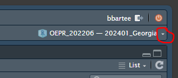

  - Select Open Project

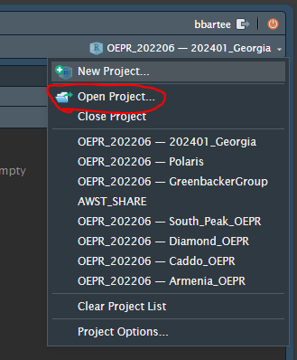

  - A pop-up will open, click on the 3 dots `...`

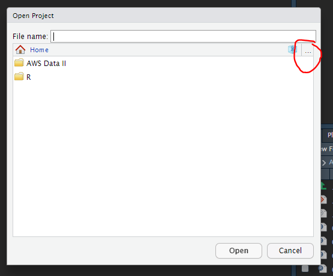

  - In the next pop-up enter `/AWST_SHARE/USA/UL_USA_SCADA_Check` in the Path

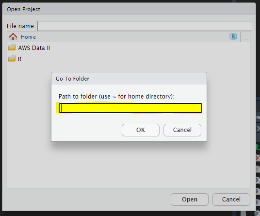

  - Next double click to click and open the `UL_USA_SCADA_Check.Rproj` file

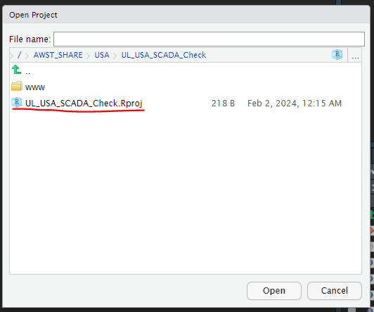

### Packages needed to have installed

The R program as written should automatically load the packages needed, but just in case you need to manually here are the steps:

R packages need:

```
  library(shiny)
  library(shinyWidgets)
  library(shinyjs)
  library(shinyalert)
  library(rmarkdown)
  library(zip)
  library(dplyr)
  library(lubridate)
  library(anytime)
  library(leaflet)
  library(tidyr)
```

1. Install a package run: `install.packages()` (e.g. `library(shiny)` is `install.packages('shiny')`)
   - Enter the package name in between the parentheses with single quotes `'shiny'`
   - if you need here is the code to load them all at once:

```r
# Define the list of packages to install
packages_to_install <- c("shiny", "shinyWidgets", "shinyjs", "shinyalert", "rmarkdown", "zip", "dplyr", "lubridate", "anytime", "leaflet", "tidyr")

# Check if the packages are already installed, install if not, then load them
installed_packages <- installed.packages()[, "Package"]
packages_to_install <- packages_to_install[!packages_to_install %in% installed_packages]
if (length(packages_to_install)) {
 install.packages(packages_to_install, dependencies = TRUE)
}

# Load the installed packages into the R session
lapply(packages_to_install, require, character.only = TRUE)
```

2. Follow all direction from R after that.

### Steps to fill out the web SCADA Check.

This section will walk you through on how to fill out the SCADA Check.

1. After you have complete the steps above.
2. You will need to run this file to start: `RunApp_Scada_Check.R`. click to open

[figure not shown]

   - Next on top right of wind that just opened click on Run App
3. This will open a new web page on your default web browser.
   - Preferably use Chrome or MS Edge.

- *1. Site Information*
  - This section is where you will enter information about your site.
  - Please read and understand the Disclaimer

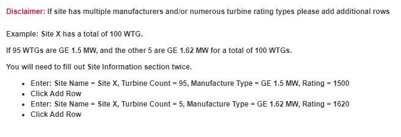

  - Steps:
    - Enter Site Name
    - Enter Turbine Count
    - Enter Manufacturer Type. (try to keep this format if possible GE 1.62 MW)
    - Enter WTG Rating (enter the kW numbers, `kW = mW x 1000 or kW = 1.62 x 1000`, kW = 1620)
    - If you make a mistake and need to re-enter data click on: *Clear Site Information Data* button
- *2. External Data Upload*
  - Stop and read Disclaimer again.

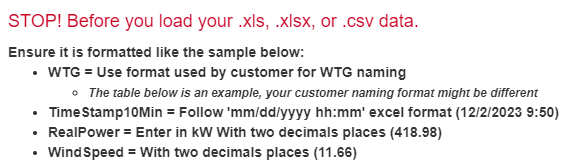

  - If you need a template to upload you data please use the download template:
  - Please make sure that the data file you upload is in this format ONLY.

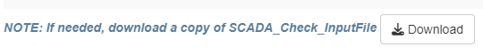

- *3. Upload External Data*
  - Click on the Browse button

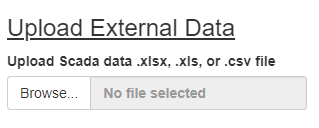

- *4. Optional Section. Additional WTG Ratings (if needed)*
  - `NOTE:` Use if site has two or more manufacturers and/or rating types; `IF NOT SKIP:`
  - Please read the Note:

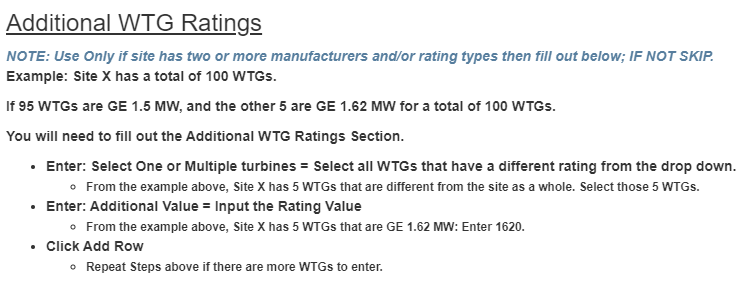

    - *How to use:*
      - First you will need to upload your external data file.
      - Click the `Select One or Multiple turbines` button
      - Select the number of WTG’s by their names. You can choose more than one.

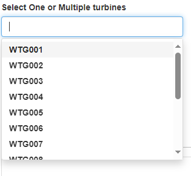

      - Then enter the kW number. (enter the kW numbers, `kW = mW x 1000 or kW = 2.62 x 1000`, kW = 2620)

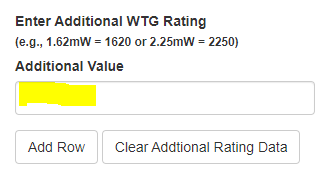

      - Finally, click *Add Row*.
      - If you make a mistake and need to re-enter data click on: *Clear Additional Rating Data* button.

- *5. Create SCADA Report* - Once all the above sections are filled out click on the `Create SCADA Check Report`. -  
- `NOTE:` - You will get a pop-up error if you forget to fill out these 2 sections: *“Site Information”, “External Data Upload”*

### Final Report and Download

When you have filled out all the information properly the SCAD report will be showing within the web page you have open.

Example:

[figure not shown]

If you want to download the SCADA Report click on *Download SCADA Report*

That is how you run the SCADA Report and download the report.

If you have any question please contact:

- Bently Bartee
- bently.bartee@ul.com